# Prediction Model on Human Activity

Ronit Rudra

Saturday, September 26, 2015

## Executive Summary

This report aims at addressing the issue of building a highly accurate model for predicting the quality of weightlifting and exercising done by the test subjects based on biometric readings. The quality is divided into 5 classes A through E and has a lot of variables it depends on. The subsequent sections outline the methodology of analyzing the data, transforming it, building train and test sets and to build a responsive moodel to accurately draw out relationship between the input(biometric) and output(quality of exercise). The model used was `Random Forest` and by using cross validation to reduce over-fitting, it was obsevered that the proposed model was very accurate in predicting with an error rate of just `0.45%`.

## 1. Reading in Data

Assuming that the required dataset is in the `current working directory`, the following steps are performed:

```r
# Load required packages
library(caret) # also loads lattice and ggplot2
# the datasets contain aretfacts such as NA, #DIv/0!,empty etc which are to be replaced with NA
train <- read.csv("pml-training.csv",na.strings=c("NA","#DIV/0!",""),stringsAsFactors=FALSE)
test<-read.csv("pml-testing.csv",na.strings=c("NA","#DIV/0!",""),stringsAsFactors=FALSE)
train$user_name <- as.factor(train$user_name)
train$classe <- as.factor(train$classe)
#str(train)        # Uncomment to see structure. Commented to reduce report size
```

- The “classe” variable is the outcome while others can be used as predictors
- The “X” variable is the row number and should be omitted from the dataset
- The “user_name” variable is also converted to factors for ease of classification

## 2. Data Transforms and Covariate Generation

1. To account for overfitting it is appropriate to split the training datset into multiple cross validation sets. In the further subheading, this step is performed during the model training itself.

```r
set.seed(1000)
splits <- createDataPartition(train$classe,p=0.65,list=FALSE)
train_train <- train[splits,-1]            # Train subset
train_test <- train[-splits,-1]            # Test subset
```

2. We also need to check the covariates (predictors) for zero variance. Covariates having zero or close to zero variance play no role in model generation and end up biasing the data. Hence, the next code chunk checks the covariates for zero variance and then removes them. This is the Level 1 near zero variance test and a second one will be performed furhter ahead.

```r
l<-nearZeroVar(train,saveMetrics = F)
train <- train[,-l]
```

3. Some variables contain a lot of NA values and are unnecessary for behaving as covariates.

```r
keep <- NULL
for(i in 1:length(train)){
    if(sum(is.na(train[,i]))/nrow(train)<0.10){
        keep <- c(keep,i)}
}
# Select Necessary Columns
train <- train[,keep]
```

In the above code block, any variables with more than 10% NA values are removed from the dataset

```r
train <- train[,-c(1,3,4,5,6)]
```

5. A second near zero variance test is performed

```r
nearZeroVar(train,saveMetrics = T)
```

```
##                      freqRatio percentUnique zeroVar   nzv
## user_name             1.100679    0.03057792   FALSE FALSE
## roll_belt             1.101904    6.77810621   FALSE FALSE
## pitch_belt            1.036082    9.37722964   FALSE FALSE
## yaw_belt              1.058480    9.97349913   FALSE FALSE
## total_accel_belt      1.063160    0.14779329   FALSE FALSE
## gyros_belt_x          1.058651    0.71348486   FALSE FALSE
## gyros_belt_y          1.144000    0.35164611   FALSE FALSE
## gyros_belt_z          1.066214    0.86127816   FALSE FALSE
## accel_belt_x          1.055412    0.83579655   FALSE FALSE
## accel_belt_y          1.113725    0.72877383   FALSE FALSE
## accel_belt_z          1.078767    1.52379982   FALSE FALSE
## magnet_belt_x         1.090141    1.66649679   FALSE FALSE
## magnet_belt_y         1.099688    1.51870350   FALSE FALSE
## magnet_belt_z         1.006369    2.32901845   FALSE FALSE
## roll_arm             52.338462   13.52563449   FALSE FALSE
## pitch_arm            87.256410   15.73234125   FALSE FALSE
## yaw_arm              33.029126   14.65701763   FALSE FALSE
## total_accel_arm       1.024526    0.33635715   FALSE FALSE
## gyros_arm_x           1.015504    3.27693405   FALSE FALSE
## gyros_arm_y           1.454369    1.91621649   FALSE FALSE
## gyros_arm_z           1.110687    1.26388747   FALSE FALSE
## accel_arm_x           1.017341    3.95984099   FALSE FALSE
## accel_arm_y           1.140187    2.73672409   FALSE FALSE
## accel_arm_z           1.128000    4.03628580   FALSE FALSE
## magnet_arm_x          1.000000    6.82397309   FALSE FALSE
## magnet_arm_y          1.056818    4.44399144   FALSE FALSE
## magnet_arm_z          1.036364    6.44684538   FALSE FALSE
## roll_dumbbell         1.022388   84.20650290   FALSE FALSE
## pitch_dumbbell        2.277372   81.74498012   FALSE FALSE
## yaw_dumbbell          1.132231   83.48282540   FALSE FALSE
## total_accel_dumbbell  1.072634    0.21914178   FALSE FALSE
## gyros_dumbbell_x      1.003268    1.22821323   FALSE FALSE
## gyros_dumbbell_y      1.264957    1.41677709   FALSE FALSE
## gyros_dumbbell_z      1.060100    1.04984201   FALSE FALSE
## accel_dumbbell_x      1.018018    2.16593619   FALSE FALSE
## accel_dumbbell_y      1.053061    2.37488533   FALSE FALSE
## accel_dumbbell_z      1.133333    2.08949139   FALSE FALSE
## magnet_dumbbell_x     1.098266    5.74864948   FALSE FALSE
## magnet_dumbbell_y     1.197740    4.30129447   FALSE FALSE
## magnet_dumbbell_z     1.020833    3.44511263   FALSE FALSE
## roll_forearm         11.589286   11.08959331   FALSE FALSE
## pitch_forearm        65.983051   14.85577413   FALSE FALSE
## yaw_forearm          15.322835   10.14677403   FALSE FALSE
## total_accel_forearm   1.128928    0.35674243   FALSE FALSE
## gyros_forearm_x       1.059273    1.51870350   FALSE FALSE
## gyros_forearm_y       1.036554    3.77637346   FALSE FALSE
## gyros_forearm_z       1.122917    1.56457038   FALSE FALSE
## accel_forearm_x       1.126437    4.04647844   FALSE FALSE
## accel_forearm_y       1.059406    5.11160942   FALSE FALSE
## accel_forearm_z       1.006250    2.95586586   FALSE FALSE
## magnet_forearm_x      1.012346    7.76679238   FALSE FALSE
## magnet_forearm_y      1.246914    9.54031189   FALSE FALSE
## magnet_forearm_z      1.000000    8.57710733   FALSE FALSE
## classe                1.469581    0.02548160   FALSE FALSE
```

The result shows that all the covariates are suitable for inclusion in the prediction model as they set the flag to `FALSE` for zero and near zero variances.

6. Plotting Predictors

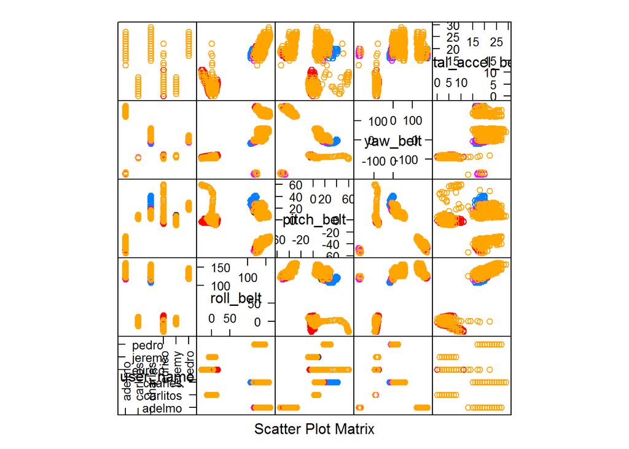

```r
# 1st 5 predictors vs outcome
featurePlot(train[,1:5],train[,54],plot="pairs")
```

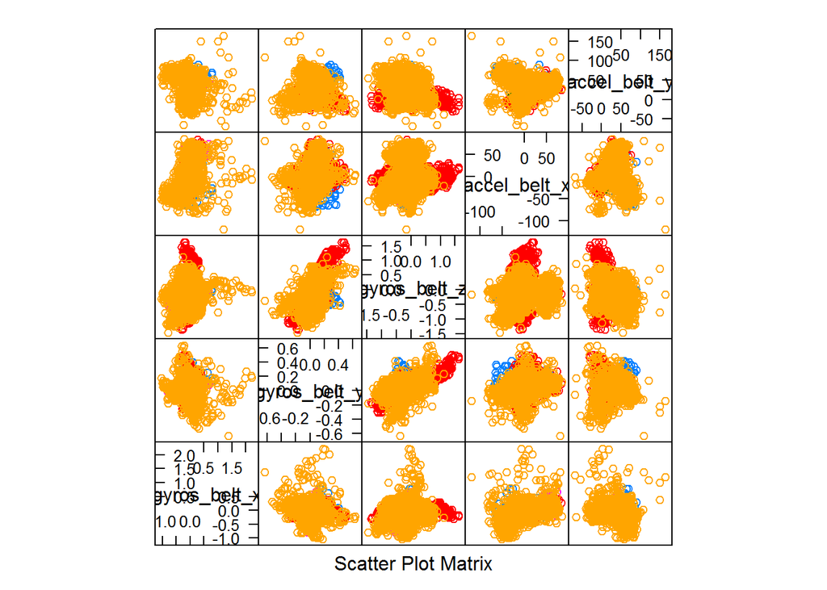

```r
# next 5 predictors vs outcome
featurePlot(train[,6:10],train[,54],plot="pairs")
```

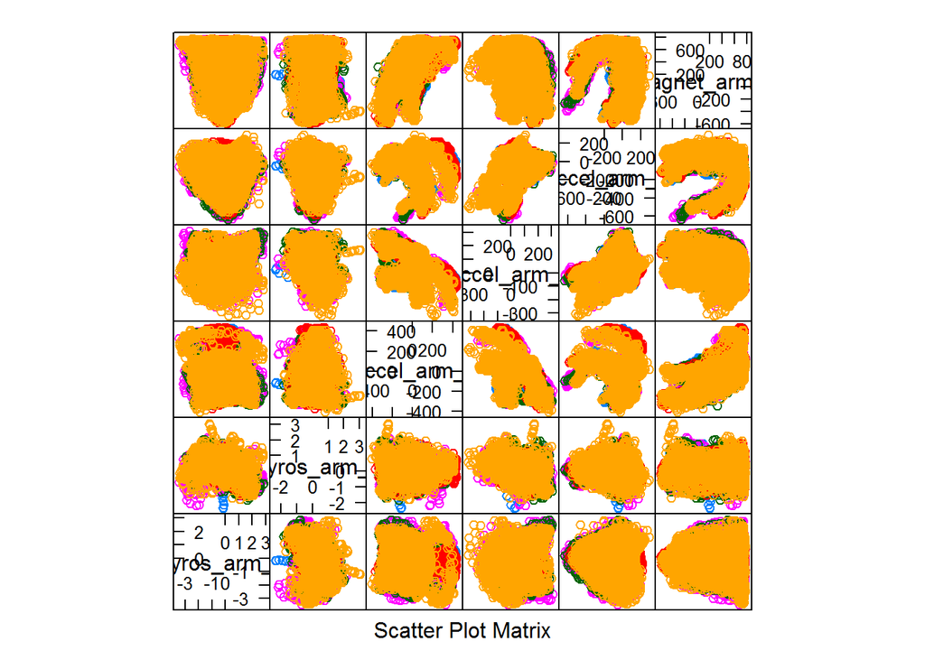

```r
# Predictors 20 through 25
featurePlot(train[,20:25],train[,54],plot="pairs")
```

## 3. Prediction model and Results

`Random Forest` was chosen to be the suitable model for classification considering: + Very High Accuracy + Multiclass output + Large number of Covariates + Overfitting can be reduced by using cross-validation

```r
# create model with 5 fold cross validation
model <- train(classe~.,data=train,method="rf",trControl=trainControl(method="cv",number=5))
# display model and confusion matrix
model$finalModel
```

```
##
## Call:
##  randomForest(x = x, y = y, mtry = param$mtry)
##                Type of random forest: classification
##                      Number of trees: 500
## No. of variables tried at each split: 29
##
##         OOB estimate of  error rate: 0.45%
## Confusion matrix:
##      A    B    C    D    E  class.error
## A 5576    3    0    0    1 0.0007168459
## B   20 3772    5    0    0 0.0065841454
## C    0   10 3402   10    0 0.0058445354
## D    0    0   22 3191    3 0.0077736318
## E    0    1    6    7 3593 0.0038813418
```

```r
# check model predictions
train_test <- train[-splits,]
pred <- predict(model, train_test)
train_test$predRight <- pred==train_test$classe
# confusion matrix
table(pred,train_test$classe)
```

```
##
## pred    A    B    C    D    E
##    A 1953    0    0    0    0
##    B    0 1328    0    0    0
##    C    0    0 1197    0    0
##    D    0    0    0 1125    0
##    E    0    0    0    0 1262
```

A random part of the training dataset was used for the prediction and the confusion matrix shows 100% classification. It could mean that the model is highly accurate or has over-fitted to the data.

**Furthermore, the tesing dataset with 20 instances was used to test the accuracy and acheived a 100% prediction rate as observed in the submission part of this assignment.**

## 4. Conclusion

The results conclude that Random Forest shows a high degree of accuracy when used for such classification purposes. The error rate is **0.45%** which is very low and within experimental limits. The confusion matrix of the 5 classes denote a negligible amount of misclassification.